*Предобработка данных.* *Нужно перекодировать переменную Genre (так как у одного фильма одновременно может быть указано несколько жанров): создадим новую переменную, которая будет нести информацию о первом (основном) из указанных жанров.* *Наиболее часто появляющимися жанрами в этой базе являются Drama, Comedy, Action, Crime, все остальные жанры объединим в категорию Other (объединяем в большую группу, так как присутствующее число наблюдений по этим категориям не достаточно для анализа).* *Нужно перекодировать переменную Runtime, чтобы осталось только число минут для каждого фильма.* *Несколько переменных содержат пропущенные значения, заменим их на медианные значения.* *Для анализа нам также понадобятся новые переменные: выручка больше или равная медианному значению, год релиза позже или равный медианному значению, оценка критиков больше или равная медианному значению, оценка аудитории больше или равная медианному значению.* *Основными переменными для анализа в этой базе для нас будут: год релиза, длительность фильма, жанр, рейтинг среди аудитории, рейтинг среди критиков и выручка.*

```r
knitr::opts_chunk$set(echo = TRUE, message = FALSE, warning = FALSE, eval = TRUE)
```

```r
library(readr)
imdb_top_1000 <- read_csv("C:/Users/Nadezhda/Desktop/imdb_top_1000.csv")
df <- imdb_top_1000[, c(3, 5:7, 9, 16)]
head(df, n = 10)
```

```
## # A tibble: 10 × 6
##    Released_Year Runtime Genre                     IMDB_Rating Meta_score  Gross
##    <chr>         <chr>   <chr>                           <dbl>      <dbl>  <dbl>
##  1 1994          142 min Drama                             9.3         80 2.83e7
##  2 1972          175 min Crime, Drama                      9.2        100 1.35e8
##  3 2008          152 min Action, Crime, Drama              9           84 5.35e8
##  4 1974          202 min Crime, Drama                      9           90 5.73e7
##  5 1957          96 min  Crime, Drama                      9           96 4.36e6
##  6 2003          201 min Action, Adventure, Drama          8.9         94 3.78e8
##  7 1994          154 min Crime, Drama                      8.9         94 1.08e8
##  8 1993          195 min Biography, Drama, History         8.9         94 9.69e7
##  9 2010          148 min Action, Adventure, Sci-Fi         8.8         74 2.93e8
## 10 1999          139 min Drama                             8.8         66 3.70e7
```

```r
library(stringr)
df[c('Time', 'Last')] <- str_split_fixed(df$Runtime, ' ', 2)
df[c('Genre1', 'Genre2', 'Genre3')] <- str_split_fixed(df$Genre, ',', 3)
sapply(df, class)
```

```
## Released_Year       Runtime         Genre   IMDB_Rating    Meta_score
##   "character"   "character"   "character"     "numeric"     "numeric"
##         Gross          Time          Last        Genre1        Genre2
##     "numeric"   "character"   "character"   "character"   "character"
##        Genre3
##   "character"
```

```r
cols.num <- c('Released_Year', 'Time')
df[cols.num] <- sapply(df[cols.num], as.numeric)
names(which(colSums(is.na(df))>0))
```

```
## [1] "Released_Year" "Meta_score"    "Gross"
```

```r
df$Gross[is.na(df$Gross)]<- median(df$Gross,na.rm = TRUE)
df$Meta_score[is.na(df$Meta_score)]<- median(df$Meta_score,na.rm = TRUE)
df$Released_Year[is.na(df$Released_Year)]<- median(df$Released_Year,na.rm = TRUE)
df$Revenue <- with(df, ifelse(Gross >= 23530892, 1, 0))
df$Rating <- with(df, ifelse(IMDB_Rating >= 7.9, 1, 0))
df$Year <- with(df, ifelse(Released_Year >= 1999, 1, 0))
df$Critics <- with(df, ifelse(Meta_score >= 79, 1, 0))
df$MainGenre <- with(df, ifelse(Genre1 == 'Drama' | Genre1 == 'Comedy' | Genre1 == 'Action' | Genre1 == 'Crime', Genre1, 'Other'))
cols.char <- c('Genre1', 'Genre2', 'Genre3', 'MainGenre', 'Revenue', 'Rating', 'Year', 'Critics')
df[cols.char] <- lapply(df[cols.char], factor)
sapply(df, class)
```

```
## Released_Year       Runtime         Genre   IMDB_Rating    Meta_score
##     "numeric"   "character"   "character"     "numeric"     "numeric"
##         Gross          Time          Last        Genre1        Genre2
##     "numeric"     "numeric"   "character"      "factor"      "factor"
##        Genre3       Revenue        Rating          Year       Critics
##      "factor"      "factor"      "factor"      "factor"      "factor"
##     MainGenre
##      "factor"
```

```r
df <- df[, c(1, 4:7, 12:16)]
```

*Далее мы будем решать задачу классификации фильмов, представленных в этой базе. Эту задачу мы будем решать при помощи кластерного анализа.* *Однако до перехода к кластерному анализу, посмотрим при помощи визуального анализа на какие группы потенциально могут быть разделены фильмы.* *Для решения этой задачи по визуализации воспользуемся алгоритмом многомерного шкалирования.* *Многомерное шкалирование хорошо подходит для задач визуального отображения близости между объектами, помещенными в двумерное пространство.* *Для такой визуализации возьмем три переменных из нашей базы - рейтинг критиков, рейтинг аудитории и доход. Одной из базовых гипотез может быть предположение о том, что наша выборка в 1000 фильмов разделится на группу, включающие фильмы с высоким рейтингом и большой выручкой и группу, объединяющую фильмы с низким рейтингом и маленькой выручкой.*

```r
df_stand <- as.data.frame(scale(df[, 2:4])) # переменные измерены в разных шкалах, требуется стандартизация
library(vegan)
nmds_result <- metaMDS(df_stand, distance = 'euclidean', k = 2)
```

```
## *** Best solution was not repeated -- monoMDS stopping criteria:
##     11: no. of iterations >= maxit
##      1: stress ratio > sratmax
##      8: scale factor of the gradient < sfgrmin
```

```r
nmds_result$stress # показатель говорит о том, насколько хорошо двумерное пространство подходит для отображения наших данных, то есть с какой точностью сработал алгоритм для наших данных (stress < 0.2 означает, что решение на два измерения хорошо подходит)
```

```
## [1] 0.1292354
```

```r
data_scores <- as.data.frame(scores(nmds_result))
data_scores <- cbind(data_scores, df[, 6:10])
```

*Визуализируем наши данные при помощи координат, которые мы получили.*

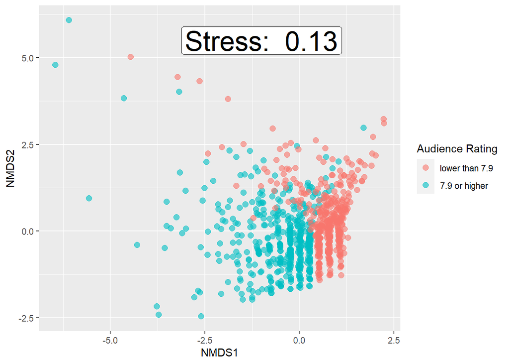

```r
library(ggplot2)
ggplot() +
geom_point(data = data_scores, aes(x = NMDS1, y = NMDS2, color = Rating), size = 2.5, alpha = 0.6) +
annotate(geom = 'label', x = -1, y = 5.5, size = 9.5, label = paste('Stress: ', round(nmds_result$stress, digits = 2))) +
scale_color_discrete(name = "Audience Rating", labels = c('lower than 7.9', '7.9 or higher'))
```

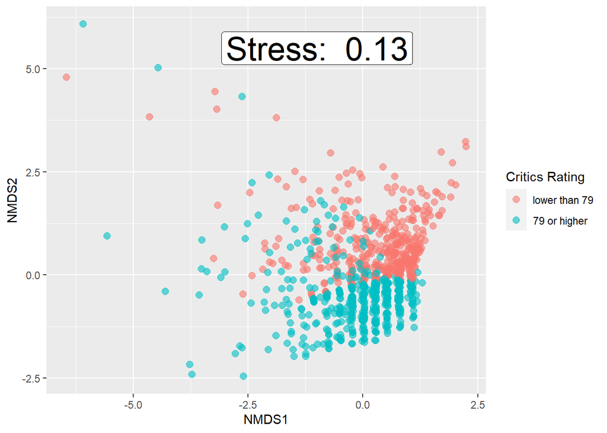

```r
ggplot() +
geom_point(data = data_scores, aes(x = NMDS1, y = NMDS2, color = Critics), size = 2.5, alpha = 0.6) +
annotate(geom = 'label', x = -1, y = 5.5, size = 9.5, label = paste('Stress: ', round(nmds_result$stress, digits = 2))) +
scale_color_discrete(name = "Critics Rating", labels = c('lower than 79', '79 or higher'))
```

*Как мы и предполагали, фильмы разделяются по рейтингу: в нашем случае горизонтальное измерение может быть описано при помощи информации об оценках аудитории, а вертикальное измерение через информацию об оценках критиков.*

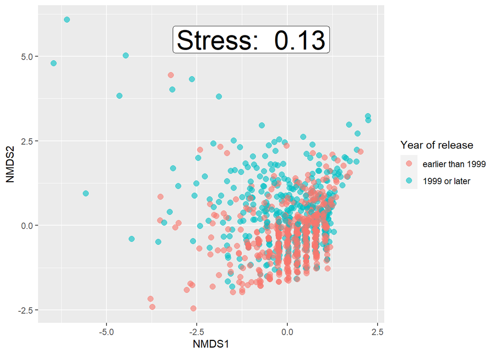

```r
ggplot() +
geom_point(data = data_scores, aes(x = NMDS1, y = NMDS2, color = Year), size = 2.5, alpha = 0.6) +
annotate(geom = 'label', x = -1, y = 5.5, size = 9.5, label = paste('Stress: ', round(nmds_result$stress, digits = 2))) +
scale_color_discrete(name = "Year of release", labels = c('earlier than 1999', '1999 or later'))
```

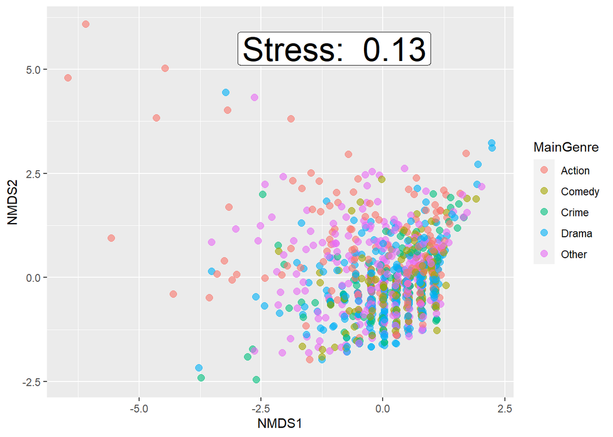

```r
ggplot() +
  geom_point(data = data_scores, aes(x = NMDS1, y = NMDS2, color = MainGenre), size = 2.5, alpha = 0.6) +
  annotate(geom = 'label', x = -1, y = 5.5, size = 9.5, label = paste('Stress: ', round(nmds_result$stress, digits = 2)))
```

*Как мы видим, в случае жанров или года релиза, визуализация не дает нам однозначно предположить, фильмы какого жанра (или какого года релиза) будут выше оценены критиками или аудиторией.* *Перейдем к задаче кластеризации. Для кластеризации мы будем использовать следующие переменные: длительность, год релиза, жанр, выручку, рейтинг аудитории и рейтинг критиков. Так как у нас и числовые, и категориальные переменные, используем алгоритм кластеризации PAM (gower distance).*

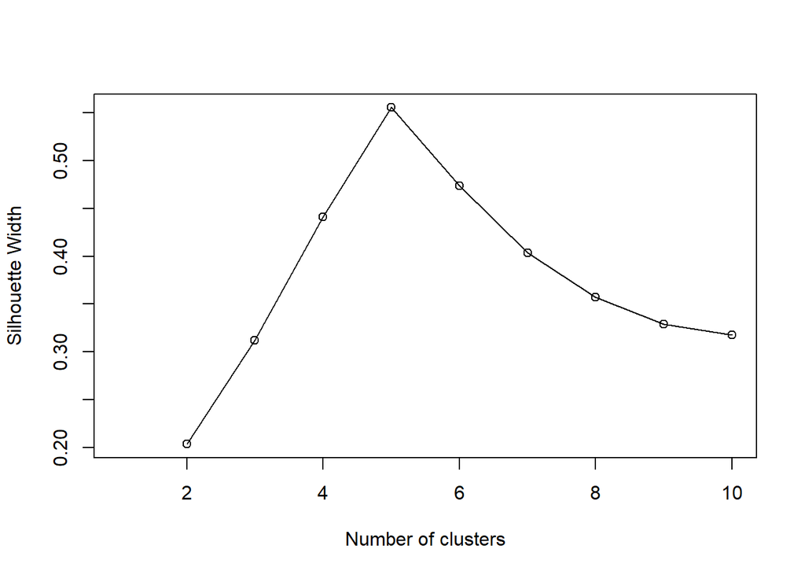

```r
library(factoextra)
library(cluster)
library(fpc)
df_clust <- df[, 1:5]
df_clust <- as.data.frame(scale(df_clust))
df_clust <- cbind(df_clust, df[, 10])
gower_dist <- daisy(df_clust, metric = "gower")
sil_width <- c(NA)
for(i in 2:10){
  pam_fit <- pam(gower_dist,
                 diss = TRUE,
                 k = i)
  sil_width[i] <- pam_fit$silinfo$avg.width
}
plot(1:10, sil_width,
     xlab = "Number of clusters",
     ylab = "Silhouette Width")
lines(1:10, sil_width) # оптимальное решение - 5 кластеров
```

```r
set.seed(123)
pam_fit <- pam(gower_dist, diss = TRUE, k = 5)
pam_fit$clusinfo
```

```
##      size  max_diss    av_diss  diameter separation
## [1,]  289 0.2591401 0.09297776 0.4129711  0.1672705
## [2,]  107 0.2810479 0.09431522 0.3966501  0.1726268
## [3,]  172 0.2770521 0.10050997 0.4277344  0.1672705
## [4,]  277 0.2128021 0.09423359 0.3749956  0.1684983
## [5,]  155 0.2199266 0.08563907 0.3419781  0.1684983
```

```r
dd <- cbind(df_clust, cluster = pam_fit$clustering)
dd$cluster <- as.factor(dd$cluster)
sapply(dd, class)
```

```
## Released_Year   IMDB_Rating    Meta_score         Gross          Time
##     "numeric"     "numeric"     "numeric"     "numeric"     "numeric"
##     MainGenre       cluster
##      "factor"      "factor"
```

```
##   cluster size ave.sil.width
## 1       1  289          0.56
## 2       2  107          0.55
## 3       3  172          0.53
## 4       4  277          0.55
## 5       5  155          0.59
```

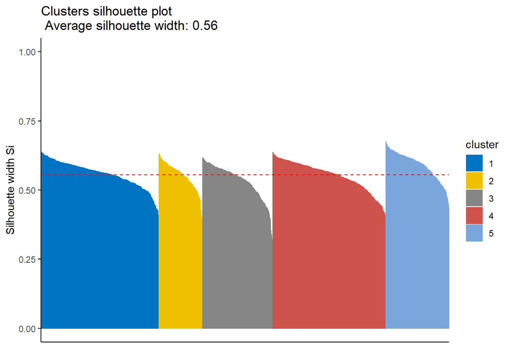

```r
fviz_silhouette(pam_fit, palette = "jco", ggtheme = theme_classic()) # проверяем насколько хорошо 5 кластеров описывают наши данные
```

```r
km_stats <- cluster.stats(gower_dist, pam_fit$clustering)
km_stats$dunn
```

```
## [1] 0.3910617
```

```r
dd <- cbind(dd, df[, 6:9])
```

*Сделаем несколько изображений, чтобы более подробно описать полученные кластеры с точки зрения жанров фильмов, года релиза, выручки и рейтингов. Как мы видим, жанр стал основной переменной, разделивший кластеры.*

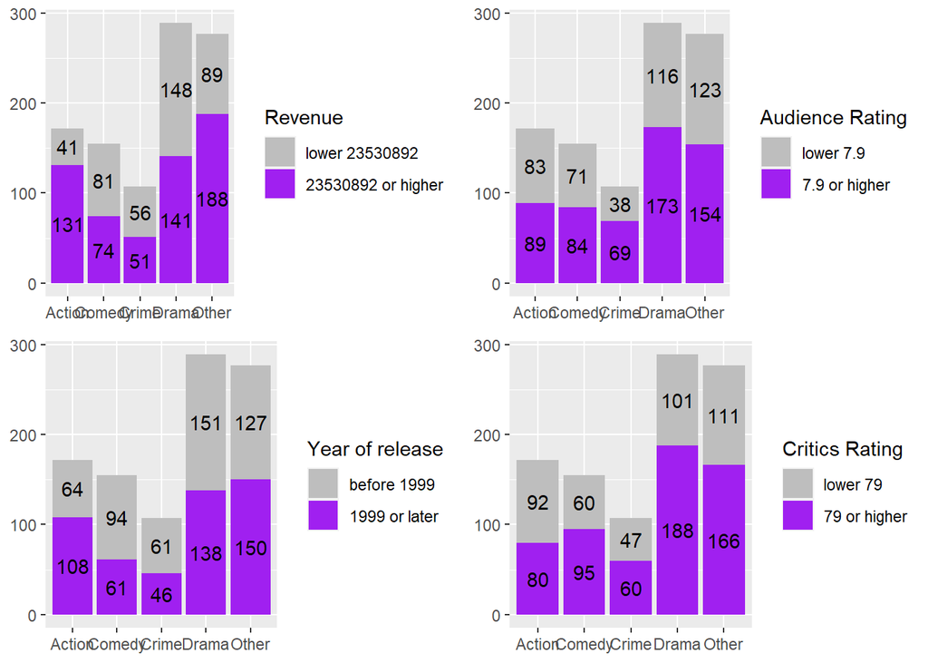

```r
library("gridExtra")
p1 <- ggplot(dd, aes(MainGenre, fill = Revenue)) +
geom_bar() +
scale_fill_manual(values = c("grey", "purple"), labels = c('lower 23530892', '23530892 or higher')) +
theme(axis.title.x = element_blank(),
axis.title.y = element_blank()) +
geom_text(aes(label= ..count..), stat = "count", position = position_stack(vjust = 0.5))
p2 <- ggplot(dd, aes(MainGenre, fill = Rating)) +
geom_bar() +
scale_fill_manual(values = c("grey", "purple"), name = 'Audience Rating', labels = c('lower 7.9', '7.9 or higher')) +
theme(axis.title.x = element_blank(),
       axis.title.y = element_blank()) +
geom_text(aes(label= ..count..), stat = "count", position = position_stack(vjust = 0.5))
p3 <- ggplot(dd, aes(MainGenre, fill = Year)) +
geom_bar() +
scale_fill_manual(values = c("grey", "purple"), name = 'Year of release', labels = c('before 1999', '1999 or later')) +
  theme(axis.title.x = element_blank(),
        axis.title.y = element_blank()) +
geom_text(aes(label= ..count..), stat = "count", position = position_stack(vjust = 0.5))
p4 <- ggplot(dd, aes(MainGenre, fill = Critics)) +
geom_bar() +
scale_fill_manual(values = c("grey", "purple"), name = 'Critics Rating', labels = c('lower 79', '79 or higher')) +
theme(axis.title.x = element_blank(),
      axis.title.y = element_blank()) +
geom_text(aes(label= ..count..), stat = "count", position = position_stack(vjust = 0.5))
grid.arrange(p1, p2, p3, p4)
```

*Далее мы будем решать задачу предсказания высокой выручки фильмов. Здесь для нас высокая выручка - равная или больше медианного значения 23530892. Для начала построим модель логистической регрессии.*

```r
df_logit <- df[, c(1:3, 5:6, 10)]
levels(df_logit$MainGenre) <- c('Other', 'Comedy', 'Action', 'Crime', 'Drama')
model_reg <- glm(Revenue ~ ., data = df_logit, family = binomial)
pR2 = 1 - model_reg$deviance / model_reg$null.deviance
pR2
```

```
## [1] 0.04596996
```

```r
library(DescTools)
PseudoR2(model_reg, c('McFadden', 'Nagel'))
```

```
##   McFadden Nagelkerke
## 0.04596996 0.08144842
```

```r
coef <- as.data.frame(exp(coef(model_reg))/(1+exp(coef(model_reg))))
coef
```

```
##                 exp(coef(model_reg))/(1 + exp(coef(model_reg)))
## (Intercept)                                           0.9673190
## Released_Year                                         0.4997598
## IMDB_Rating                                           0.4827740
## Meta_score                                            0.4986066
## Time                                                  0.5012788
## MainGenreComedy                                       0.2387508
## MainGenreAction                                       0.2257425
## MainGenreCrime                                        0.2366327
## MainGenreDrama                                        0.4119085
```

```r
library(performance)
check_collinearity(model_reg)
```

```
## # Check for Multicollinearity
##
## Low Correlation
##
##           Term  VIF   VIF 95% CI Increased SE Tolerance Tolerance 95% CI
##  Released_Year 1.16 [1.09, 1.26]         1.08      0.86     [0.79, 0.91]
##    IMDB_Rating 1.17 [1.10, 1.27]         1.08      0.86     [0.79, 0.91]
##     Meta_score 1.18 [1.11, 1.28]         1.09      0.85     [0.78, 0.90]
##           Time 1.14 [1.08, 1.24]         1.07      0.88     [0.80, 0.93]
##      MainGenre 1.08 [1.03, 1.20]         1.04      0.92     [0.84, 0.97]
```

[figure not shown]

```r
library(sjPlot)
plot_model(model_reg, vline.color = 'red')
```